# Лабораторная работа №3

Имитационное моделирование

Ибрахим Мохсейн Алькамаль

1032225432@rudn.ru

Российский университет дружбы народов

2026-09-03

# Информация

## Докладчик

- Ибрахим Мохсейн Алькамаль
- Российский университет дружбы народов

# Цель работы

- Изучить принципы агентного моделирования на примере Daisyworld.
- Реализовать взаимодействие чёрных и белых маргариток с окружающей средой.
- Исследовать динамику модели.
- Провести эксперименты с различными параметрами.
- Проанализировать численность агентов, температуру и солнечную светимость.

# Выполнение лабораторной работы

## Инициализация проекта

- Подготовлен проект `lab03/project`.
- Выполнен скрипт `setup_project.jl`.
- Инициализирована структура проекта.
- Установлены необходимые зависимости.

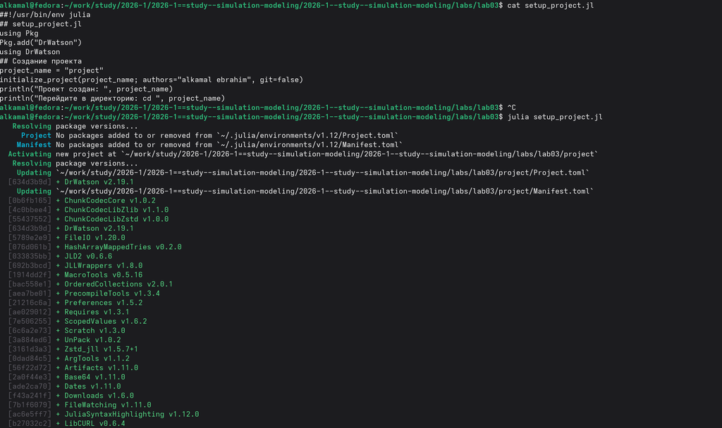

Рисунок 1: Инициализация проекта и установка зависимостей Julia

## Проверка проектного окружения

- Окружение активировано командой `julia --project=.`.
- Установленные пакеты проверены с помощью `Pkg.status()`.
- Проверено наличие `Agents`, `CairoMakie`, `DrWatson` и `DataFrames`.

[figure not shown]

Рисунок 2: Проверка установленных пакетов проектного окружения

## Создание файлов модели

- Создан файл `src/daisyworld.jl`.
- Создан скрипт `scripts/daisyworld.jl`.
- Реализована базовая визуализация Daisyworld.

[figure not shown]

Рисунок 3: Создание файлов модели и скрипта базовой визуализации Daisyworld

## Базовая визуализация

- Выполнен скрипт `scripts/daisyworld.jl`.
- Получены состояния модели на шагах 1, 5 и 40.
- Изображения сохранены в каталоге `plots/`.

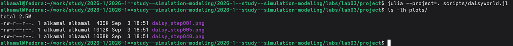

Рисунок 4: Результаты выполнения базовой визуализации модели Daisyworld

## Генерация файлов

- Подготовлен `scripts/daisyworld_literary.jl`.
- Выполнена обработка с помощью `tangle.jl`.
- Сформированы Julia-скрипт, Quarto-документ и Jupyter Notebook.

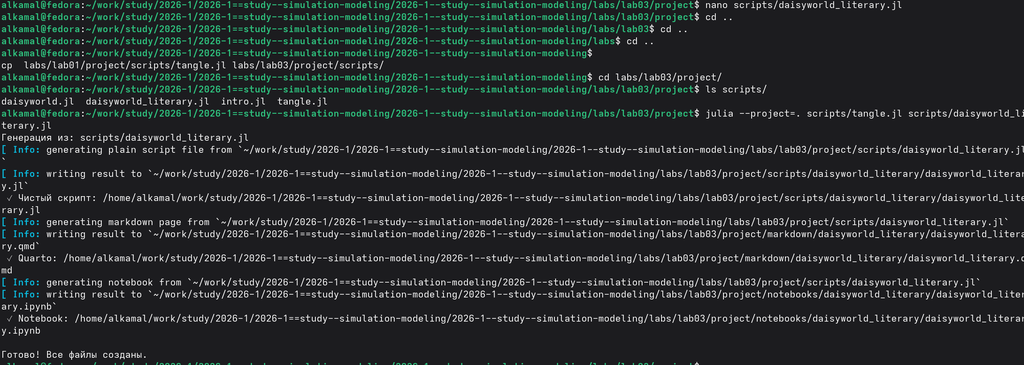

Рисунок 5: Генерация скрипта, документа Quarto и Jupyter Notebook из литературного кода

## Базовая модель в Jupyter

- Выполнен `daisyworld_literary.ipynb`.
- Инициализирована модель Daisyworld.
- Настроено отображение агентов.
- Заданы параметры температурной карты.

[figure not shown]

Рисунок 6: Выполнение литературной версии базовой визуализации Daisyworld в Jupyter Notebook

## Скрипт анимации

- Подготовлен `scripts/daisyworld-animate.jl`.
- Настроено отображение агентов и температурного поля.
- Функция `abmvideo` формирует анимацию из 60 кадров.

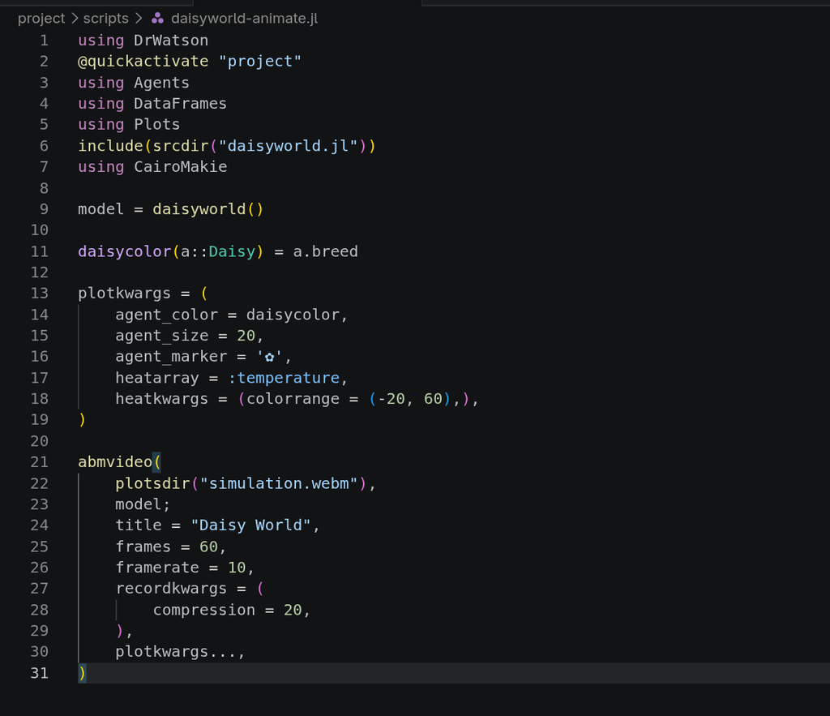

Рисунок 7: Реализация скрипта анимации агентной модели Daisyworld

## Генерация анимации

- Выполнен `scripts/daisyworld-animate.jl`.
- Использовано активное проектное окружение.

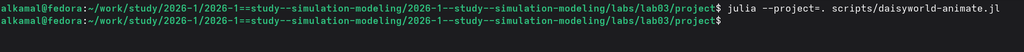

Рисунок 8: Выполнение скрипта генерации анимации Daisyworld

## Результат анимации

- Показана динамика Daisyworld во времени.
- Отображены агенты модели.
- Представлено температурное поле от −20 до 60.

[figure not shown]

Рисунок 9: Визуализация динамики агентов и температурного поля Daisyworld

## Подготовка скриптов

- Подготовлены `daisyworld-count.jl` и `daisyworld-count_literary.jl`.
- Выполнена обработка литературной версии через `tangle.jl`.
- Созданы Julia-скрипт, Quarto-документ и Jupyter Notebook.

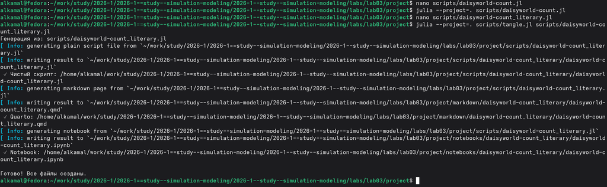

Рисунок 10: Генерация файлов для анализа количества агентов Daisyworld

## Сбор данных

- Сформирован набор данных для чёрных и белых маргариток.
- Начальная солнечная светимость — `1.0`.
- Выполнено 1000 модельных шагов.
- Результаты сохранены в `agent_df`.

[figure not shown]

Рисунок 11: Сбор данных о количестве чёрных и белых маргариток за 1000 шагов моделирования

## Подготовка литературного скрипта

- Подготовлен `daisyworld-luminosity_literary.jl`.
- Выполнен `tangle.jl`.
- Созданы Julia-скрипт, Quarto-документ и Jupyter Notebook.

[figure not shown]

Рисунок 12: Генерация файлов для исследования изменения солнечной светимости Daisyworld

## Анализ динамики

- Построены три связанных графика.
- Отображена численность чёрных и белых маргариток.
- Показаны температура и солнечная светимость.
- Сопоставлена динамика с параметром `solar_luminosity`.

[figure not shown]

Рисунок 13: Графики количества маргариток, температуры и солнечной светимости Daisyworld

## Серия экспериментов

- Подготовлен скрипт `daisyworld__param.jl`.
- Проведены эксперименты с различными параметрами.
- Результаты сохранены в каталоге `plots/`.

[figure not shown]

Рисунок 14: Результаты выполнения серии экспериментов с параметрами модели Daisyworld

## Литературная версия экспериментов

- Создан `daisyworld__param_literary.jl`.
- Выполнена обработка с помощью `tangle.jl`.
- Созданы Julia-скрипт, Quarto-документ и Jupyter Notebook.

[figure not shown]

Рисунок 15: Генерация файлов для серии параметрических экспериментов Daisyworld

## Перебор параметров

- Последовательно перебираются наборы параметров.
- Для каждого набора создаётся отдельная модель.
- Состояние сохраняется на шагах 1, 5 и 40.
- Изменяются `max_age` и `init_white`.

[figure not shown]

Рисунок 16: Выполнение серии экспериментов с различными параметрами модели Daisyworld

## Моделирование солнечной светимости

- Выполнен скрипт `daisyworld-luminosity.jl`.
- Получен график `daisy_luminosity.png`.
- Результат сохранён в каталоге `plots/`.

[figure not shown]

Рисунок 17: Выполнение моделирования с изменением солнечной светимости и сохранение результата

## Настройка эксперимента

- Исследуются несколько комбинаций параметров.
- Анализируется численность чёрных и белых маргариток.
- Анализируются температура и солнечная светимость.
- Выполняется 1000 шагов со сценарием `:ramp`.

[figure not shown]

Рисунок 18: Настройка эксперимента для исследования динамики модели Daisyworld

## Анализ численности агентов

- Выполнен `daisyworld-count__param.jl`.
- Исследованы комбинации `max_age` и `init_white`.
- Сформированы четыре графических результата.

[figure not shown]

Рисунок 19: Формирование графиков численности маргариток для различных параметров модели

## Документирование анализа

- Подготовлен `daisyworld-count__param_literary.jl`.
- Выполнен `tangle.jl`.
- Сформированы Julia-скрипт, Quarto-документ и Jupyter Notebook.

[figure not shown]

Рисунок 20: Генерация файлов для анализа численности маргариток при различных параметрах

## Параметрические эксперименты

- Для каждого набора создаётся отдельная модель.
- Выполняется 1000 шагов моделирования.
- Строятся графики численности маргариток.
- Рассматриваются четыре комбинации `max_age` и `init_white`.

[figure not shown]

Рисунок 21: Выполнение серии экспериментов по численности маргариток Daisyworld

## Исследование солнечной светимости

- Выполнен `daisyworld-luminosity__param.jl`.
- Использованы различные комбинации `max_age` и `init_white`.
- Использован сценарий `ramp`.
- Сформированы четыре результата.

[figure not shown]

Рисунок 22: Формирование результатов исследования солнечной светимости при различных параметрах

## Литературная версия исследования

- Подготовлен `daisyworld-luminosity__param_literary.jl`.
- Выполнена обработка через `tangle.jl`.
- Сформированы Julia-скрипт, Quarto-документ и Jupyter Notebook.

[figure not shown]

Рисунок 23: Генерация файлов для исследования солнечной светимости при различных параметрах Daisyworld

# Выводы

- Реализована и исследована агентная модель Daisyworld.
- Выполнена визуализация состояния модели.
- Создана анимация динамики Daisyworld.
- Проведён сбор данных о численности маргариток.
- Исследовано изменение солнечной светимости.
- Рассмотрены различные значения `max_age` и `init_white`.
- Результаты представлены в виде графиков и Jupyter Notebook.